# Over The Air Update Guide

## Table of Contents

**Abstract**

Over-The-Air (OTA) update is a wireless delivery of new software updates or configurations to an embedded device. Using the concept of an identity key (IRK) within the Internet-of-Things (IoT) world, OTA proves to be an efficient way of distributing firmware updates or upgrades.

This document describes the OTA library for the SimpleLink™ Wi-Fi® CC3x20 family of devices from Texas Instruments™ and explains how to prepare a new cloud-ready update to be loaded by the OTA library.

The SimpleLink MCU portfolio offers a single development environment that delivers flexible hardware, software and tool options for customers developing wired and wireless applications. With 100 percent code reuse across host MCUs, Wi-Fi® , Bluetooth® low energy, Sub-1 GHz devices and more, choose the MCU or connectivity standard that fits your design. A one-time investment with the SimpleLink software development kit (SDK) allows you to reuse often, opening the door to create unlimited applications. For more information, visit: [www.ti.com/simplelink](http://www.ti.com/simplelink/).

# 1 Introduction

The OTA library for the SimpleLink CC3x20 family of solutions simplifies the effort of MCU applications to access the cloud and download new upgrades (such as new firmware applications, service packs, and user files) in a secured and fail-safe manner, while ensuring the integrity of the process.

**The OTA library exposes a simple API set:**

- OTA_init()
- OTA_set()
- OTA_get()
- OTA_run()

This API set is compatible for non-OS and OS-based platforms.

## 1.1 System Block Diagram

Figure 1 shows the block diagram of the OTA system:

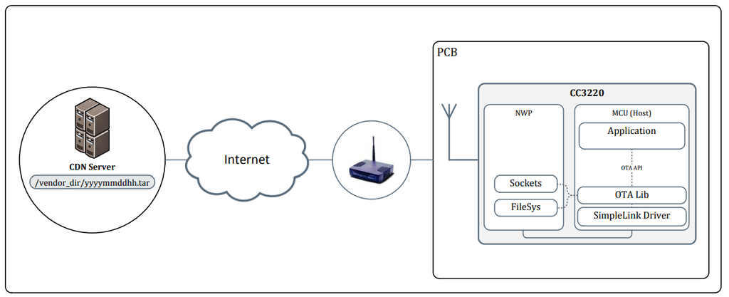

**Fig. 1: OTA System Diagram**

The OTA library supports the following cloud CDN vendors:

- Dropbox™ API V2
- Github

The OTA library implements a simple HTTP client (TCP) to connect to the CDN server. This client can be configured by the host application as follows:

- Non-secured (Connect to CDN running HTTP server)
- Secured (Connect to CDN running HTTPS server)
  - Server authentication (required by default)
  - Domain name verification (required by default)
  - No server authentication

The software upgrade application and user files should be put in an archive tar file. By default, all files are non-secured and fail-safe. The vendor can change the attributes of a file (such as secured, signature, certificate file name, and so forth) by adding entry to a command file (ota.cmd), which is in JSON format and included in the tar archive.

## 1.2 OTA Software Block diagram

Figure 2 shows the block diagram of the OTA software:

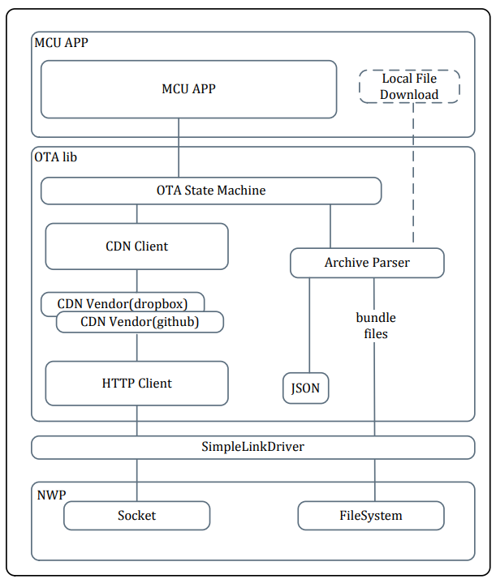

**Fig. 2: OTA Software Block Diagram**

## 1.3 Terminology and Abbreviations

Table 1 lists terminology and abbreviations used in this documentation.

**Table 1: Terminology**

| Term | Description |
| --- | --- |
| `OTA` | Over-the-Air |
| `CDN` | Content delivery network. In the relation to the OTA lib, CDN relates to the servers that contain the new package. |
| `ACM` | Account manager |
| `CSP` | Cloud storage provider |
| `HTTP` | Hypertext transfer protocol |
| `URL` | Uniform resource locator |
| `URI` | Uniform resource identifier |
| `REST` | Representational state transfer |
| `JSON` | JavaScript object notation |

# 2 High-Level Description for Adding OTA Capability

Existing host applications can be expanded to have OTA capability by using the OTA library and the OTA sample application as a reference. The OTA sample application works on the CC32xx and CC31xx devices with an MSP432™ microcontroller (MCU) as the host.

## 2.1 Software Installations and Downloads

Follow the SDK Getting Started Guide (CC31xx or CC32xx) to prepare development environment as follows:

1. Download the newest version of Code Composer Studio™ (CCS).
2. Download the latest CC32xx or CC31xx SDK.
3. Download the latest UniFlash tool, select CC32xx device, and start the Image Creator tool inside.
4. Install the SimpleLink Starter Pro on your mobile phone.

## 2.2 OTA Process Briefly

The following steps explain, at a high level, the steps to prepare and run the OTA application:

1. Create a developer account in the selected CDN server (Dropbox, Github, or custom).
2. Open the OTA sample application and change the selected CDN server info.
3. Compile the OTA sample application.
4. Create a TAR file with the host application and all other required files.
5. Upload the TAR file into the CDN server.
6. Open the UART terminal to view the application logs.
7. Using the Image Creator, prepare an image containing the OTA application, and program the device.
8. When the host application starts the OTA process, download and run the new host application.

**NOTE**: Replacing the TAR file in the CDN server with a newer one should re-invoke the OTA download.

# 3 Running the Default OTA Sample Application

The OTA sample application provides a basic application with Cloud OTA and provisioning capabilities. This application is described in more detail in Section 5 and can be used as a basis for developing a target application.  
The Cloud OTA sample application supports:

- OS: FreeRTOS or TI-RTOS
- CC32XX variant: CC3220R, CC3220S, CC3220SF
- Development tools: CCS8.0 or higher.

The following sections are for specific a CC32xx variant and OS; change the names for a different OS or CC32xx variant. For the CC3220R, use the name CC3220S.

**NOTE**: The OTA library produces compilation errors. Open a developer account on Dropbox or Github, and get a token to be used in `<SDK_INSTALL_DIR>\source\ti\net\ota\otauser.h`. For Dropbox cloud, see Section 8.1 and Section 4.1.

## 3.1 Building the Cloud OTA CCS Project for CC3220SF

Install the CC32xx SDK and import two CCS projects:

- OTA library project
- OTA application project

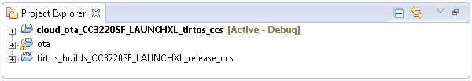

  **Fig. 3: Selected Cloud OTA Project Names**
1. Import the OTA library project using CCS IDE from the following location: `<SDK_INSTALL_DIR>\source\ti\net\ota\ccs`

   **NOTE**: This project should not be copied to the CCS workspace.
2. Import the Cloud OTA project using CCS IDE from the following location, according to CC3220SF flavor and the desired OS:
   - For FreeRTOS and CC3220SF devices: `<SDK_INSTALL_DIR>\examples\rtos\CC3220SF_LAUNCHXL\demos\cloud_ota\freertos\ccs`
   - For TI-RTOS and CC3220SF devices: `<SDK_INSTALL_DIR>\examples\rtos\CC3220SF_LAUNCHXL\demos\cloud_ota\tirtos\ccs`
3. Configure the cloud server:
   - Open a developer account on Dropbox or Github. For instructions, see Section 8.1 and Section 4.1.
   - Copy the given cloud server token into the OTA lib user configuration file in: `<SDK_INSTALL_DIR>\source\ti\net\ota\otauser.h`

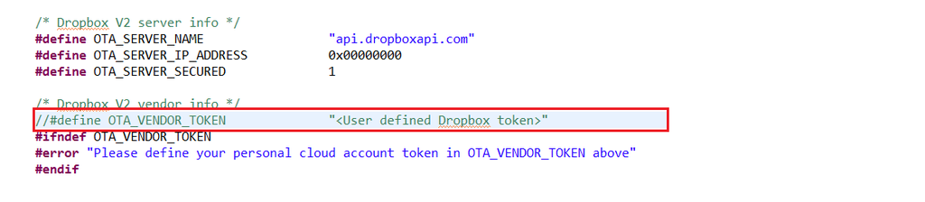

4. Configure OTA special compilation flags:
   - OTA lib : Define `SL_ENABLE_OTA_DEBUG_TRACES` in `otauser.h` for detailed OTA library debug prints.
   - OTA project:
     - Define `DISABLE_OTA_SWITCH_TRIGGER` in `cloud_ota.c` to start the OTA process after 5 pings,  
       and not to wait for an external trigger (CC3220LP button).
     - Define `OTA_LOOP_TESTING` to continue running OTA attempts when the return value is `NO_UPDATE`, `OLDER_VERSION`.
5. Compile the project and produce a cloud_ota.bin file to be programmed by the UniFlash.
   1. Build OTA library project – ota
   2. Build OTA sample application project – `cloud_ota_CC3220SF_LAUNCHXL_tirtos_ccs`
   3. Output bin file is located in the projects workspace directory `<cc32xx_sdk_workspace_dir>\cloud_ota_CC3220SF_LAUNCHXL_tirtos_ccs\Debug\cloud_ota_CC3220SF_LAUNCHXL_tirtos_ccs.bin`

   **NOTE**: This section demonstrates building the project with CCS. Building the OTA lib and application using a different tool chain is similar. For more information, please advise the Quick start guide.

## 3.2 Program by UniFlash Tool With Image Creator Inside

The following instructions describe how to program the device.

1. Open UniFlash and select CC32xx device, as shown in Figure 5:

[figure not shown]

   **Fig. 5: Choose Your Device**
2. Start Uniflash tool and select New Project, fill the project name, and click create project (for debug mode, the device must be opened first in development mode).
3. Go to: Files → Trusted Root-Certificate Catalog, and select `<SDK_INSTALL_DIR>\tools\cc32xx_tools\certificateplayground\certcatalogPlayGroung20160911.lst`, as shown in Figure 6 (do not use the default).

[figure not shown]

   **Fig. 6: Trusted Root-Certificate Catalog**
4. Now, go to: Files → Service Pack, and select the latest service pack (the bin file is located at: `<SDK_INSTALL_DIR>\tools\cc32xx_tools\servicepack-cc3x20`), as shown in Figure 7:

[figure not shown]

   **Fig. 7: Service Pack File Name**
5. Go to: Files → User Files, and select the following, as shown in Figure 8:

[figure not shown]

   **Fig. 8: User Files**
- Certificates files:
  - `<SDK_INSTALL_DIR>\tools\cc32xx_tools\certificate-playground\dummy-root-ca-cert`
  - `<SDK_INSTALL_DIR>\tools\cc32xx_tools\certificate-playground\dummy-trusted-ca-cert`
- OTA certificate:
  - `<SDK_INSTALL_DIR>\tools\cc32xx_tools\ota-example-cert\dummy_ota_vendor_cert`  
    A certificate of the public key which correspond to the private key that was used to generate `ota.sign`. Provided with the SDK, is a dummy certificate, for demonstration purposes.

**IMPORTANT !**: OTA certificate MUST be a standard x509 valid certificate. The certificate structure is not validated before installation, and must be checked by the user beforehand.

- Certificates for Dropbox and Github:
  - Download the Dropbox and Github Root CA certificates (that is, `DigCert_High_Assurance_CA.der`).
- User files MCU image (see Figure 9):
  - `<cc32xx_sdk_workspace_dir>\cloud_ota_CC3220SF_LAUNCHXL_tirtos_ccs\Debug\cloud_ota_CC3220SF_LAUNCHXL_tirtos_ccs.bin`

[figure not shown]

    **Fig. 9: User Files**
1. Configure the device to STA role.
2. Click Create OTA to produce a tar file to be put in the cloud server. Once you click `Create OTA`, a message window would pop, as shown in Figure 10. Here, a vendor provides a key (secp256r1 elliptic curve private key) with which the OTA meta-data files would be signed. Provided with the SDK, is a dummy private key, for demonstration purposes, here: `<SDK_INSTALL_DIR>\tools\cc32xx_tools\certificate-playground\ota-example-cert\dummy_ota_vendor_key`. For security reasons it is very recommended not to skip this option. The output file `2016091917_CC3220SF_CC3220SF_OTA.tar` should be put in the cloud directory, as shown in the image below:

[figure not shown]

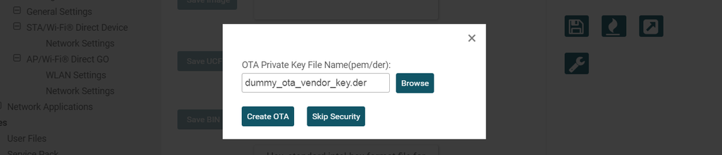

   **Fig. 10: OTA cmd signing**
3. Configure in `otauser.h`:

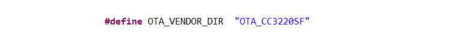

4. Click on Program Image (Create and Program), as shown in Figure 11. The image is now programmed to the device.

[figure not shown]

   **Fig. 11: Generate Image**

## 3.3 Running a Sample Application

After programming the OTA sample application in the device and putting the OTA tar file in the cloud, press reset to start the OTA process. The major steps that the sample application executes are as follows:

1. Connect to AP through an existing profile, or by the provisioning process.
2. Send pings and wait for the CC3220LP button click to start the OTA.
3. Configure the OTA library with the CDN server details.
4. Run the OTA process, initiated from external trigger (button on the CC3220LP board):
   1. Connect to the CDN HTTPS server.
   2. Request for directory content, and download the TAR archive file.
   3. Extract TAR archive files, including the file `mcuflashimg.bin`, into the serial flash.
5. After the download is finished, set `IMAGE_TESTING` mode and reset the MCU.
6. On successful system tests, set `IMAGE_COMMIT` and continue running the new MCU image.

   **NOTE**: A new OTA process can be initiated again by the user. The download process is only re-invoked if a new TAR file is uploaded to the CDN or when the user configures it to ignore the newer version check by `#define OTA_LOOP_TESTING` in `cloud_ota.c` file.

# 4 Adding OTA Capability Into an Embedded Software Application

This application note focuses on showcasing the ability of the CC32xx device to receive firmware updates and any related files over an Internet-enabled Wi-Fi interface.

## 4.1 Updating OTA Definitions

The OTA library has support for the following CDN vendors:

- Dropbox™ API V2
- Github

This section describes how to use one of these CDN vendors. To add support for another CDN vendor, refer to Section 10. To run the OTA lib, a vendor must have an account in one of the supported CDNs to distribute the software updates.  
For more information how to open an account, refer to Section 8. The CDN setting, including the credentials, are updated in the `otauser.h` file with the selected directory and token.

### 4.1.1 otauser.h

This file is found here: `<cc32xx_sdk_workspace_dir>\source\ti\net\ota`. This file allows the user to configure the following options for the OTA process:

- Select the OTA server vendor by defining `OTA_SERVER_TYPE`:

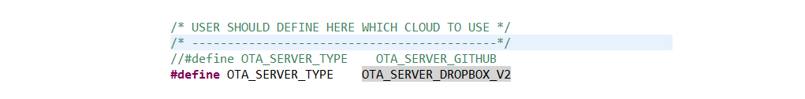

- Define the vendor server information section:

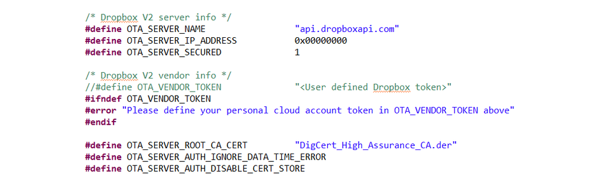

The host application can set the server IP address in `OTA_SERVER_IP_ADDRESS` instead of server name.  
By default, the lib requires server authentication and domain name verification. From a security perspective, the previous requirements are essential, and TI recommends using this mode. If the custom server is not secured, or server authentication and domain name verification are not required, `OTA_SERVER_ROOT_CA_CERT` can be undefined.

## 4.2 Using OTA lib in the Main Application

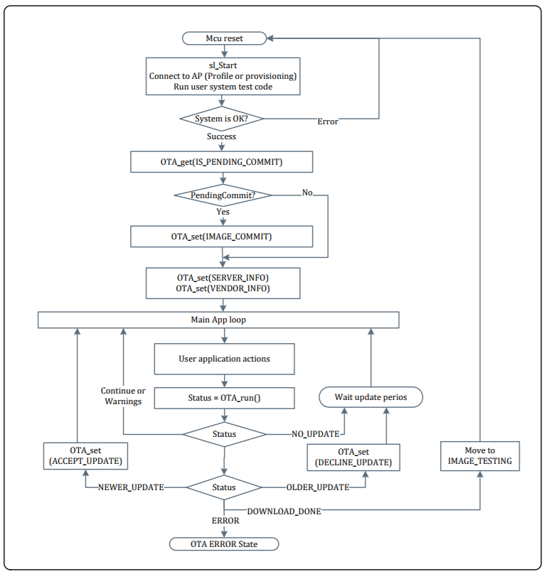

**Fig. 12: Basic OTA Application Flow Chart**

### 4.2.1 Initiate the OTA Library

The host application must define a global buffer for the use of the OTA lib, and provide this buffer while it initiates the OTA:

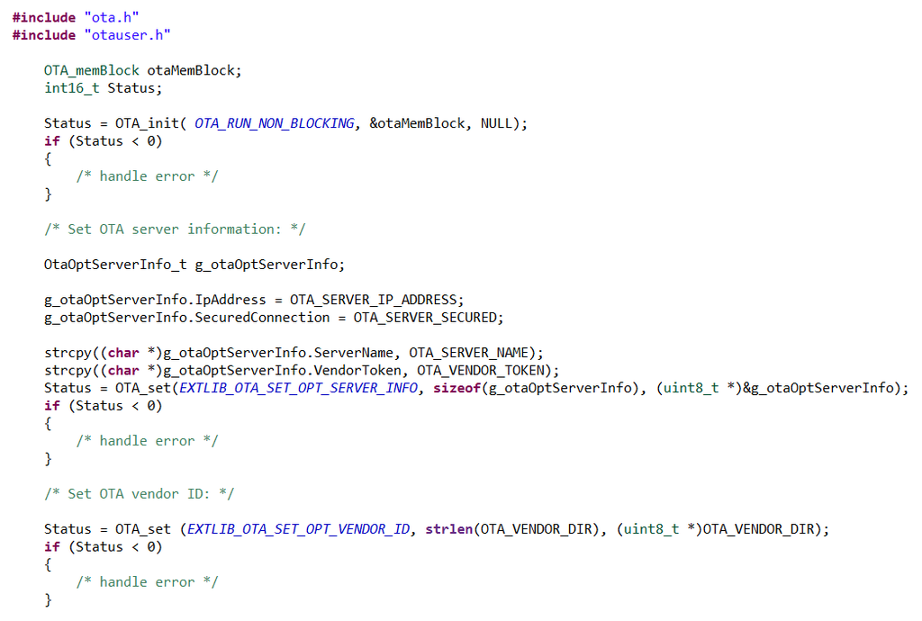

### 4.2.2 Running the OTA Process

The OTA process runs in steps side-by-side with the main application. The user should continue to call the OTA process as long as the return value is `OTA_RUN_STATUS_CONTINUE`. The following example shows a simple main loop of a non-OS application:

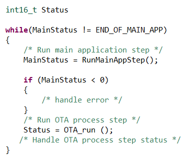

The possible OTA process return values are:

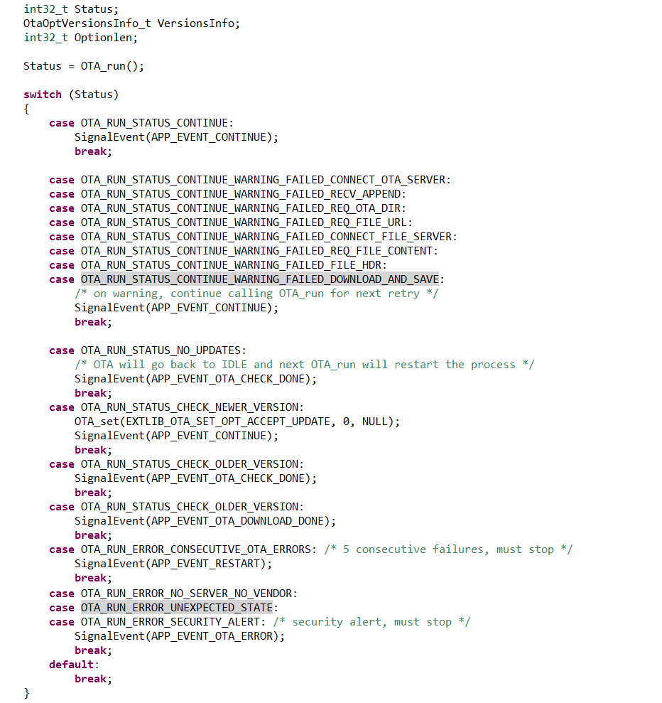

### 4.2.2 OTA Commit Process

Upon a successful completion of the OTA process (Status `RUN_STAT_DOWNLOAD_DONE`), all software upgrade package files are stored in the serial flash in bundle mode, but are still not in use. The host application should move the bundle into `IMAGE_TESTING` mode by calling `sl_Stop()` with a timeout different than 0, and then resetting the MCU.

After the reset, the bundle files are used and the application should check if the new image works correctly (for example, connect to a network, run some network tests, and so forth). On a successful system test, the application should check if the image is in `WAIT_FOR_COMMIT` mode, and call the OTA lib to perform the commit. After the commit, the files are used and a rollback is not allowed.  
On system test failure, the application must reset the MCU to perform a rollback of all files to the previous image:

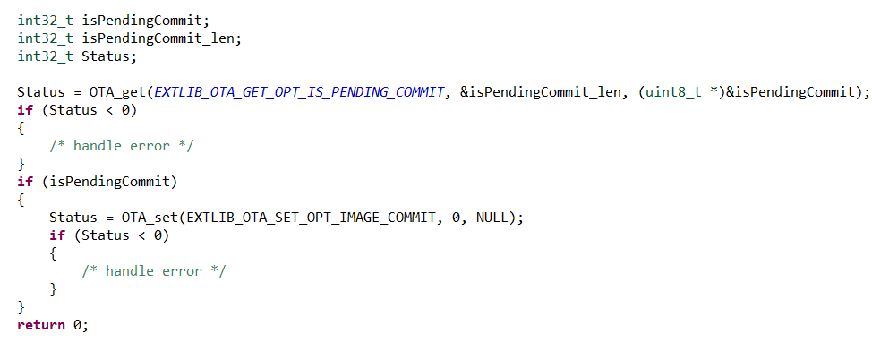

# 5 Sample OTA Application

The sample OTA application is implemented by a state machine (SM). The SM is started on response to `sl_Start()`, and driven by NWP events and application events, as shown in Table 2 and Table 3.

**Table 2: OTA App States**

[output not shown]

**Table 3: NWP Events**

[output not shown]

1. *Ignored.

## 5.1 Application State Machine

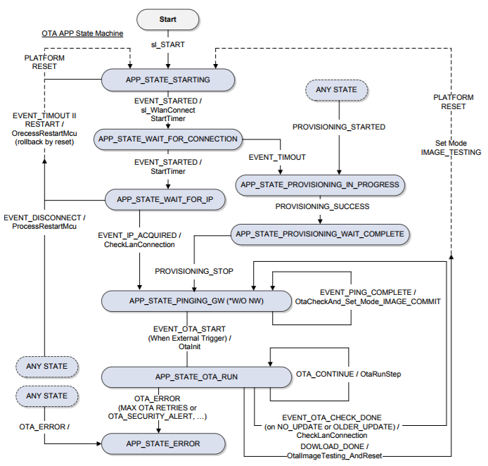

**Fig. 13: Sample Application State Machine**

## 5.2 Provisioning Connection

The host application uses an existing profile to connect to an AP. If no profile exists, or it is unable to connect to any of the existing profile, the host application has the option to add a new profile using the TI provisioning process.

The provisioning process automatically starts if no connection is available. The user should use the Mobile Provisioning application to add a new profile.

More about provisioning can be found in the Provisioning Application Report.  
More about the mobile application can be found in the Provisioning User Guide.

## 5.3 OTA External Trigger

After establishing a connection, the host application continues to check the connection to the AP endlessly (PING).

To start the OTA process, initiate an external trigger. The external trigger is defined according to the different platform used:

- CC32xx – Switch 2
- MSP432 – Switch P1.1

After the external trigger is initiated, the host application starts the OTA process.

# 6 Creating OTA Software Upgrade Package

The software upgrade package is an archive tar file (not compressed) that contains all relevant files. The files should be placed in hierarchy directories, as shown in Figure 14.

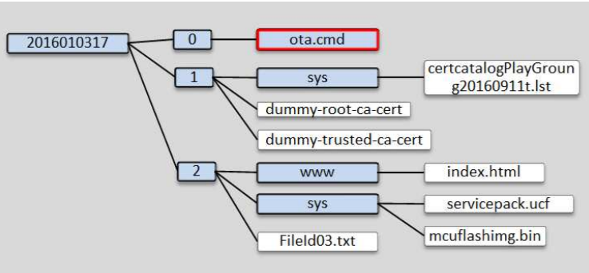

**Fig. 14: Directory Hierarchy**

The name of the root directory should contain the package version number. This name should be constructed of numerical digits that can be compared to the existing package version number, and based on that to determine if an upgrade is required. The example above uses the date/time numeric number with the format: YYYYMMDDHH.

The directories 0, 1, and 2 are used to set the package files download order:

- Directory 0 – Contains archive metadata file named `ota.cmd` and it’s signature `ota.sign`. `ota.sign` is a digital signature of `ota.cmd` which is generated with elliptic curve cryptography (ECDSA SECP256R1), and used for authentication. Furthermore, to ensure system integrity, each file in the package must have an entry in the metadata file (`ota.cmd`) and vice versa, with a corresponding SHA-256 digest value calculated by UniFlash tool. Each file in the package can also have an optional signature and certificate file name.
- Directory 1 – Contains certificates that must be downloaded for the files that are using it.
- Directory 2 – Files using metadata from directory 0, certificates from directory 1, or other any files.

The files and directory names should have the same name as in the serial flash. For files in the root directory, the leading slash is removed (certificate filename limitation). The base tar file should be produced using the UniFlash tool and clicking Create OTA, as shown in Figure 15. This base tar file only has the MCU image and the service pack.

[figure not shown]

**Fig. 15: Create OTA**

The user can add user files to the existing tar file by un-archiving the files into local directory, adding the user files,  
and archiving the directory into the tar file.

Limitations:

- New folder structure which is easy to access and follow through
- The filename includes the full path (with subdirectory), and is limited to 100 bytes
- The certificate file name is limited to 20 bytes
- Certificate store (`certstore.lst`): MaxRequestSize = 7000, secured, fail safe, public write
- Service pack : For ROM (patches) : MaxRequestSize = 131072, fail safe
- Service pack : For TDFLASH : MaxRequestSize = 262144, no fail safe, secured, public write

# 7 Preparing ota.cmd Metadata File

The `ota.cmd` file is the first file in the OTA archive files, and it is in JSON array format. Each JSON object represents one file in the archive. All files must have a JSON object in the `ota.cmd`.

The metadata supports the following JSON tokens:

- digest - The SHA-256 hash value of the file.
- certificate – The certificate file name
- signature_base64 – The file signature in Base64 format, with a size of 345 bytes.
- secured – 1 if the file is secured (default non-secured)
- bundle – 1 if the file is part of the bundle (default bundle 1).
- filename – The name of the file, the same name in both the TAR file and in the target SFLASH

The following code example contains object for a secured file, `FileId03.txt`, with a signature and certificate. The second object is a service pack file with a signature. The third object is an mcu image, with a signature and certificate. The last object is a certificate with which `ota.cmd` was signed.

```
[
    {
        "digest":"34941765501d16a4ab776c3a74d89945f1a2575c5893069f62ffbe803f344549",
        "certificate": "dummy-trusted-ca-cert",
        "signature_base64": "kc8XfFOfMfr4HBJiPxTRHyb99d2uOoICme0AYU94+...",
        "secured": 1,
        "bundle": 0,
        "filename": "/local/FileId03.txt"
    },
    {
        "digest":"251b5394428e5b82a02c598199055f19ea945d9803f73a850588cc12f6eec684",
        "certificate":"",
        "signature_base64": "EEC6GZG1Oq6Agigmb2f9ny9rNK2Mg9hFClpgMhd4jCW/...",
        "secured": 1,
        "bundle": 1,
        "filename": "/sys/servicepack.ucf"
    },
    {
        "digest":"d89cdff2f5c7784fa2551f265f0ebe16a7179f51fc6cd36e78ecee7285ec3075",
        "certificate": "dummy-root-ca-cert",
        "signature_base64": "dRTARlzLFKAog34ZUareCmo9j2lrHnvc+v3qqW9C/...",
        "secured": 1,
        "bundle": 1,
        "filename": "/sys/mcuflashimg.bin"
    },
    {
        "digest":"a160b855d7a00a6002922181377249a80ecd6a738d23e1dd8976c8bb7fad1bcb",
        "certificate":"",
        "signature_base64":"",
        "certificate": "dummy-root-ca-cert",
        "secured":0,
        "bundle": 0,
        "filename":"dummy_ota_vendor_cert.der"
    }
]
```

# 8 Distributing Software Upgrades Through a Cloud Service

## 8.1 Getting Started With the e Dropbox™ Cloud Delivery Network (CDN)

The purpose of the following steps is to describe working with the Dropbox server to run the cloud OTA application. Before following the next instructions, you must create a Dropbox account.

1. On the main page, open the Developers tab, as shown in Figure 16.

[figure not shown]

   **Fig. 16: Developers Tab**
2. Choose Create your app, as shown in Figure 17:

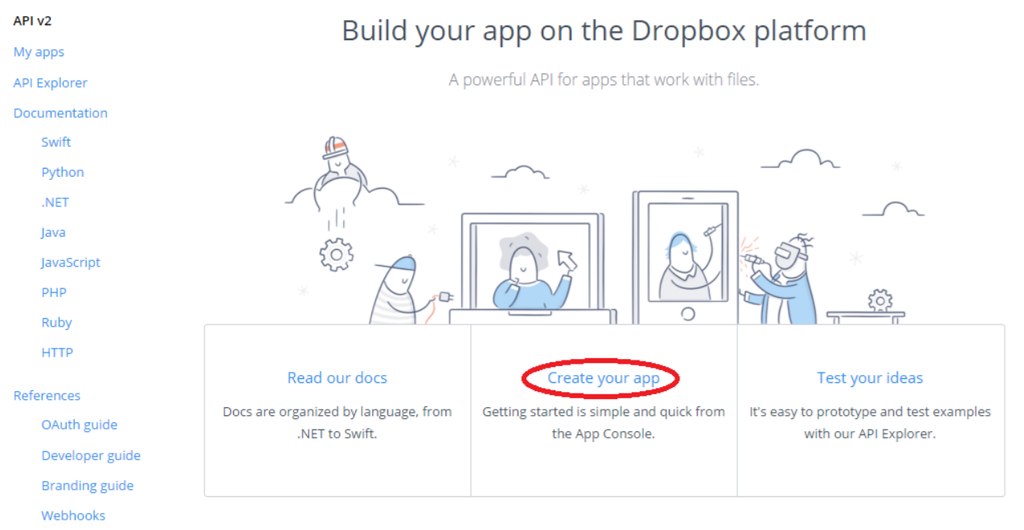

   **Fig. 17: Create Your App**
3. Choose Dropbox API. For access type, choose App folder, as shown in Figure 18, and name the application (for example, “OTA_R2”), then press Create app.

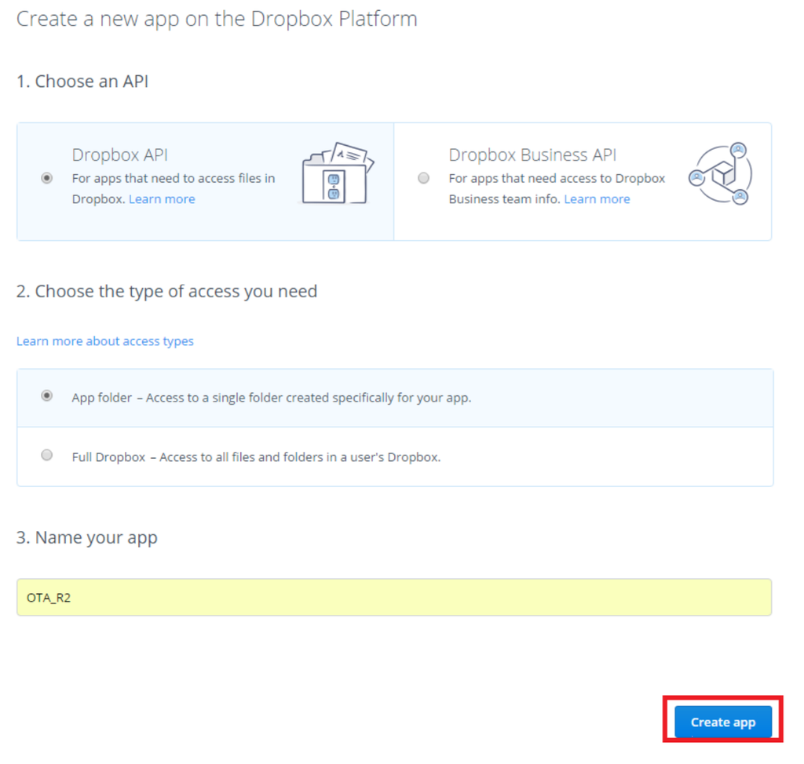

   **Fig. 18: Create App**
4. Select the App key and App secret, as shown in Figure 19.

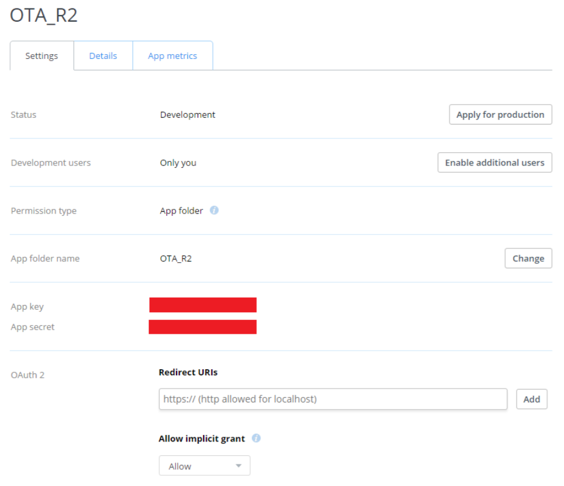

   **Fig. 19: App Key**
5. Generate the access token, as shown in Figure 20.

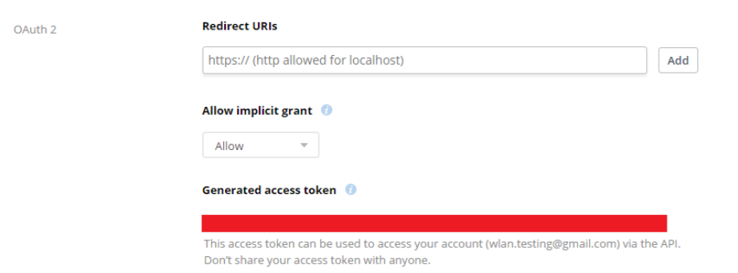

   **Fig. 20: Generate Access Token**
6. Authorize the app with the previously generated token, app key, and secret.
7. After the app is authorized, save the authorization bearer Token Key. This is the OTA Vendor Token which should be placed in the `otauser.h` file.
8. An Apps folder appears at the main page, as shown in Figure 21.

[figure not shown]

   **Fig. 21: Apps Folder**
9. Open Apps. The previously created folder should appear. Open the folder, as shown in Figure 22.

[figure not shown]

   **Fig. 22: OTA Vendor Directory**
10. Create new folder and name it with the same name which appears in the `otauser.h` file under the define `OTA_VENDOR_DIR`. Put the TAR file here. For information on how to create a TAR file, refer to Section 6.